# Bayes Theorem and Probability - Day 03

## Binomial Probability Distt

1. Yes and No
2. Trials are repeated ones and they follow Bernoulli Pattern
3. Every Trial that we execute has only two options
4. Formula of Binom Dist:: nCx *p^x* q^(n-x)

Here n = Total Trials/Sample x = Instances p = probability of Success q = (1-p) = Prob of Failure

### Note: In Software, we have success of trials and prob of Success.

The prob of Failure is Unstated.

Library: scipy.stats k , n , p

1. A LED bulb manufacturing company regularly conducts quality checks at specified periods on the products it manufactures. Historically, the failure rate for LED light bulbs that the company manufactures is 5%. Suppose a random sample of 10 LED light bulbs is selected. What is the probability that a) None of the LED bulbs are defective? Ans:0.5987 b) Exactly one of the LED bulbs is defective? Ans: 0.3151 c) Two or fewer of the LED bulbs are defective? Ans: 0.9885 | 0,1,2 d) Three or more of the LED bulbs are defective Ans: 0.011503

```python
# Import the Required Library
import scipy.stats as stats
```

```python
# Sample as 0
stats.binom.pmf(k = 0, n = 10, p = 0.05)
```

```
0.5987369392383789
```

```python
# Exactly one of the LED bulbs is defective? Ans: 0.3151
stats.binom.pmf(k = 1, p = 0.05, n  = 10)
```

```
0.31512470486230504
```

```python
# Two or fewer of the LED bulbs are defective? # 0.9885
stats.binom.cdf(n = 10, p = 0.05, k = 2) # find the prob of 0,1 and max 2

# p(0) + p(1) +p(2)  binom.cdf
```

```
0.9884964426207031
```

```python
# Three or more of the LED bulbs are defective Ans: 0.11503
1 - stats.binom.cdf(n = 10, p = 0.05, k = 2)
```

```
0.01150355737929687
```

1. In the old days, there was a probability of 0.8 of success in any attempt to make a telephone call. (This often depended on the importance of the person making the call, or the operator's curiosity!) Calculate the probability of having 7 successes in 10 attempts.
1. Hospital records show that of patients suffering from a certain disease, 75 die of it. What is the probability that of 6 randomly selected patients, 4 will recover? Ans: 0.03295

```python
stats.binom.pmf(n = 10, k = 7, p = 0.8)
```

```
0.20132659200000014
```

```python
stats.binom.pmf(n = 6,k = 4, p = 0.25)
```

```
0.032958984375
```

### Poisson Prob Distribution

1. The occurence of the events if successive in nature is independent of previous occurences.
2. The happening of the events should have the element of randomness...(Meaning No Pattern)
3. In simple words, it means that the events should be absolutely random which means if the event is not random, the poisson distribution will not be applicable in such a scenario.
4. These occurences happened on the basis of TIME INTERVAL...

e.g. people visiting atm to withdraw money is a ex of randomness and the visit of any person in ATM is not affected by successive person.

Some More Examples

1. Stock Market Price Movement
2. Visiting Dentist After Appointment
3. Govt Deciding Demonitisation
4. Plane Landing on Airport

Note: If Happening of the Event is not Random, it cannot be included in the purview of Poisson Distribution

On average, a household receives 9.5 telemarketing phone calls per week. Using the Poisson probability distribution formula, find the probability that a randomly selected household receives exactly 6 telemarketing phone calls during a given week. Ans: 0.0764

```python
from scipy.stats import poisson
```

```python
poisson.pmf(mu = 9.5, k = 6) # mu: mean no of occurences and k = instance
```

```
0.07642079604012611
```

Cynthia’s Mail Order Company provides free examination of its products for 7 days. If not completely satisfied, a customer can return the product within that period and get a full re- fund.

According to past records of the company, an average of 2 of every 10 products sold by this company are returned for a refund. Find the probability that exactly 6 of the 40 products sold by this company on a given day will be returned for a refund.

```python
stats.poisson.pmf(mu = 8, k = 6)
```

```
0.12213821545677205
```

The number of work-related injuries per month in a manufacturing plant is known to follow a Poisson distribution, with a mean of 2.5 work-related injuries a month. What is the probability that in a given month,

a) No work related injuries occur?

b) At least one work-related injury occurs?

```python
stats.poisson.pmf(k = 0, mu = 2.5)
```

```
0.0820849986238988
```

```python
# Atleast 01 Work Related Injury Occurs
1 - stats.poisson.pmf(k = 0, mu = 2.5)
```

```
0.9179150013761012
```

A Life Insurance agent sells on the average 3 life insurance policies per week. Use the Poisson law to calculate the probability that in a given week, he will sell

b. 2 or more but less than 5 policies?

```python
# k  = 4 and min = 2
stats.poisson.cdf(k = 4, mu = 3) - stats.poisson.cdf(k = 1, mu = 3)
```

```
0.6161149710523164
```

# Diabetes Dataset

1. KNN
2. Logistic Regression
3. Decision tree
4. Naive Bayes

```python
import numpy as np
import pandas as pd
import matplotlib.pyplot as plt
import seaborn as sns
```

```python
diabetes = pd.read_csv(".//Downloads/diabetes.csv")
```

```python
diabetes.head()
```

|  | Pregnancies | Glucose | BloodPressure | SkinThickness | Insulin | BMI | DiabetesPedigreeFunction | Age | Outcome |
| --- | --- | --- | --- | --- | --- | --- | --- | --- | --- |
| 0 | 6 | 148 | 72 | 35 | 0 | 33.6 | 0.627 | 50 | 1 |
| 1 | 1 | 85 | 66 | 29 | 0 | 26.6 | 0.351 | 31 | 0 |
| 2 | 8 | 183 | 64 | 0 | 0 | 23.3 | 0.672 | 32 | 1 |
| 3 | 1 | 89 | 66 | 23 | 94 | 28.1 | 0.167 | 21 | 0 |
| 4 | 0 | 137 | 40 | 35 | 168 | 43.1 | 2.288 | 33 | 1 |

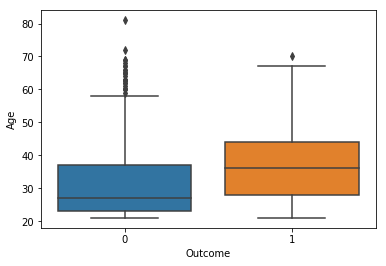

```python
# If Age has any Impact on Target Variable:: Outcome
sns.boxplot(x = "Outcome", y = "Age", data = diabetes)

# People who are diabetes have higher age bracket
```

```python
# Generate the Statistics of People who have higher age and are diabetic
diabetes.groupby("Outcome")["Age"].describe()

# Range of People who are diabetic is {27+-47}
```

| Outcome | count | mean | std | min | 25% | 50% | 75% | max |
| --- | --- | --- | --- | --- | --- | --- | --- | --- |
| 0 | 500.0 | 31.190000 | 11.667655 | 21.0 | 23.0 | 27.0 | 37.0 | 81.0 |
| 1 | 268.0 | 37.067164 | 10.968254 | 21.0 | 28.0 | 36.0 | 44.0 | 70.0 |

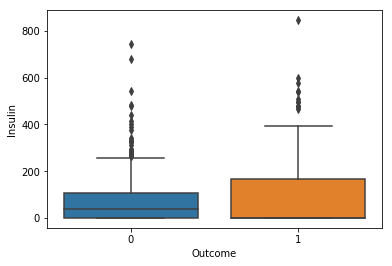

```python
# Diabetic::Insulin vs Outcome
sns.boxplot(x="Outcome", y = "Insulin", data=diabetes)
```

```python
diabetes.groupby("Outcome")["Insulin"].describe()
```

| Outcome | count | mean | std | min | 25% | 50% | 75% | max |
| --- | --- | --- | --- | --- | --- | --- | --- | --- |
| 0 | 500.0 | 68.792000 | 98.865289 | 0.0 | 0.0 | 39.0 | 105.00 | 744.0 |
| 1 | 268.0 | 100.335821 | 138.689125 | 0.0 | 0.0 | 0.0 | 167.25 | 846.0 |

```python
# Insulin == 0 and then what about outcome
diabetes[diabetes.Insulin==0]["Outcome"].value_counts()

# There are diabetic patients who are not dependent on Insulin
```

```
0    236
1    138
Name: Outcome, dtype: int64
```

```python
diabetes.head()
```

|  | Pregnancies | Glucose | BloodPressure | SkinThickness | Insulin | BMI | DiabetesPedigreeFunction | Age | Outcome |
| --- | --- | --- | --- | --- | --- | --- | --- | --- | --- |
| 0 | 6 | 148 | 72 | 35 | 0 | 33.6 | 0.627 | 50 | 1 |
| 1 | 1 | 85 | 66 | 29 | 0 | 26.6 | 0.351 | 31 | 0 |
| 2 | 8 | 183 | 64 | 0 | 0 | 23.3 | 0.672 | 32 | 1 |
| 3 | 1 | 89 | 66 | 23 | 94 | 28.1 | 0.167 | 21 | 0 |
| 4 | 0 | 137 | 40 | 35 | 168 | 43.1 | 2.288 | 33 | 1 |

1. RULE: If BP is >=160 then Higher Glucose Concentration
2. Anything Above 140 is considered to high Glucose Levels
3. Normal Glucose Level 80 to 100

```python
# Blood Pressure should not be 0 and so is the case of Skin Thickness followed
# Glucose
# Lets Pull the Data Frame where Glucose is 0
diabetes[diabetes.Glucose==0]
```

|  | Pregnancies | Glucose | BloodPressure | SkinThickness | Insulin | BMI | DiabetesPedigreeFunction | Age | Outcome |
| --- | --- | --- | --- | --- | --- | --- | --- | --- | --- |
| 75 | 1 | 0 | 48 | 20 | 0 | 24.7 | 0.140 | 22 | 0 |
| 182 | 1 | 0 | 74 | 20 | 23 | 27.7 | 0.299 | 21 | 0 |
| 342 | 1 | 0 | 68 | 35 | 0 | 32.0 | 0.389 | 22 | 0 |
| 349 | 5 | 0 | 80 | 32 | 0 | 41.0 | 0.346 | 37 | 1 |
| 502 | 6 | 0 | 68 | 41 | 0 | 39.0 | 0.727 | 41 | 1 |

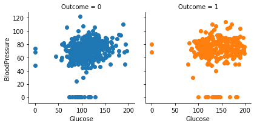

```python
# Facet Grid of Glucose
d = sns.FacetGrid(diabetes, col = "Outcome", hue = "Outcome")
d.map(plt.scatter, "Glucose", "BloodPressure")
```

```python
# Find the Statistics of Glucose Variable where the Outcome is 0
diabetes.groupby("Outcome").Glucose.describe()
```

| Outcome | count | mean | std | min | 25% | 50% | 75% | max |
| --- | --- | --- | --- | --- | --- | --- | --- | --- |
| 0 | 500.0 | 109.980000 | 26.141200 | 0.0 | 93.0 | 107.0 | 125.0 | 197.0 |
| 1 | 268.0 | 141.257463 | 31.939622 | 0.0 | 119.0 | 140.0 | 167.0 | 199.0 |

```python
# Imputting the Glucose Values where it is 0
a = diabetes[(diabetes.Glucose==0) & (diabetes.Outcome == 0)]["Glucose"].replace(to_replace = 0,
                                                                             value = 109.98, inplace = True)
```

```python
# Column Name - without Space| One Word Outcome, Glucose diabetes.Glucose
# Data.Column - When it doesnt work. Column name is "Glucose Systolic"
```

```python
diabetes[(diabetes["Outcome"]==1) & (diabetes["Glucose"]==0)]
```

[output not shown]

```python
a.Glucose.replace(to_replace = 0, value = 109.98)
```

[output not shown]

```python
diabetes[(diabetes["Outcome"]==0) & (diabetes["Glucose"]==0)]["Glucose"].replace(to_replace = 0,
                                                                             value = 109.98, inplace = True)
```

```python
diabetes[(diabetes["Outcome"]==1) & (diabetes["Glucose"]==0)]
```

[output not shown]

```python
def imputezero(glucose, outcome):
    if (outcome==0 and glucose==0):
        return(glucose.replace(0,109.98, inplace=True))
    else:
        return(glucose.replace(0,140, inplace=True))
```

```python
0 = 109 and 1 = 140
```

```python
diabetes.groupby("Outcome")["Glucose"].apply(lambda x:x.replace(0,109.98))
```

```
0      148.0
1       85.0
2      183.0
3       89.0
4      137.0
5      116.0
6       78.0
7      115.0
8      197.0
9      125.0
10     110.0
11     168.0
12     139.0
13     189.0
14     166.0
```

[output cut: 47 more lines]

```python
for i in np.arange(1,len(diabetes["Glucose"])):
    if((diabetes.loc[i,"Outcome"]==0) & (diabetes.loc[i,"Glucose"]==0)):
        diabetes.loc[i, "Glucose"]=109.98
    elif((diabetes.loc[i,"Outcome"]==1) & (diabetes.loc[i,"Glucose"]==0)):
        diabetes.loc[i, "Glucose"]=140
```

```python
diabetes.loc[:, "Outcome"] # Synatx loc(Row Index, Column Index)
```

```
0      1
1      0
2      1
3      0
4      1
5      0
6      1
7      0
8      1
9      1
10     0
11     1
12     0
13     1
14     1
```

[output cut: 47 more lines]

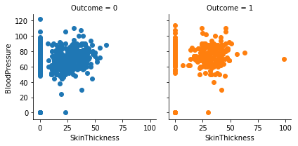

```python
# Facet Grid of Glucose
d = sns.FacetGrid(diabetes, col = "Outcome", hue = "Outcome")
d.map(plt.scatter, "SkinThickness", "BloodPressure")
```

```python
diabetes.SkinThickness.describe()
```

```
count    768.000000
mean      20.536458
std       15.952218
min        0.000000
25%        0.000000
50%       23.000000
75%       32.000000
max       99.000000
Name: SkinThickness, dtype: float64
```

```python
diabetes.groupby("Outcome").BloodPressure.describe()
```

| Outcome | count | mean | std | min | 25% | 50% | 75% | max |
| --- | --- | --- | --- | --- | --- | --- | --- | --- |
| 0 | 500.0 | 68.184000 | 18.063075 | 0.0 | 62.0 | 70.0 | 78.0 | 122.0 |
| 1 | 268.0 | 70.824627 | 21.491812 | 0.0 | 66.0 | 74.0 | 82.0 | 114.0 |

```python
for i in np.arange(1,len(diabetes["Glucose"])):
    if((diabetes.loc[i,"Outcome"]==0) & (diabetes.loc[i,"SkinThickness"]==0)):
        diabetes.loc[i, "SkinThickness"]=19.664000
    elif((diabetes.loc[i,"Outcome"]==1) & (diabetes.loc[i,"SkinThickness"]==0)):
        diabetes.loc[i, "SkinThickness"]=22.164179
```

```python
for i in np.arange(1,len(diabetes["Glucose"])):
    if((diabetes.loc[i,"Outcome"]==0) & (diabetes.loc[i,"BloodPressure"]==0)):
        diabetes.loc[i, "BloodPressure"]=68.184
    elif((diabetes.loc[i,"Outcome"]==1) & (diabetes.loc[i,"BloodPressure"]==0)):
        diabetes.loc[i, "BloodPressure"]=70.824627
```

```python
diabetes.groupby("Outcome").BMI.describe()
```

| Outcome | count | mean | std | min | 25% | 50% | 75% | max |
| --- | --- | --- | --- | --- | --- | --- | --- | --- |
| 0 | 500.0 | 30.304200 | 7.689855 | 0.0 | 25.4 | 30.05 | 35.300 | 57.3 |
| 1 | 268.0 | 35.142537 | 7.262967 | 0.0 | 30.8 | 34.25 | 38.775 | 67.1 |

```python
for i in np.arange(1,len(diabetes["Glucose"])):
    if((diabetes.loc[i,"Outcome"]==0) & (diabetes.loc[i,"BMI"]==0)):
        diabetes.loc[i, "BMI"]=30.304200
    elif((diabetes.loc[i,"Outcome"]==1) & (diabetes.loc[i,"BMI"]==0)):
        diabetes.loc[i, "BMI"]=35.142537
```

```python
diabetes.head(25)
```

|  | Pregnancies | Glucose | BloodPressure | SkinThickness | Insulin | BMI | DiabetesPedigreeFunction | Age | Outcome |
| --- | --- | --- | --- | --- | --- | --- | --- | --- | --- |
| 0 | 6 | 148.0 | 72.000000 | 35.000000 | 0 | 33.600000 | 0.627 | 50 | 1 |
| 1 | 1 | 85.0 | 66.000000 | 29.000000 | 0 | 26.600000 | 0.351 | 31 | 0 |
| 2 | 8 | 183.0 | 64.000000 | 22.164179 | 0 | 23.300000 | 0.672 | 32 | 1 |
| 3 | 1 | 89.0 | 66.000000 | 23.000000 | 94 | 28.100000 | 0.167 | 21 | 0 |
| 4 | 0 | 137.0 | 40.000000 | 35.000000 | 168 | 43.100000 | 2.288 | 33 | 1 |
| 5 | 5 | 116.0 | 74.000000 | 19.664000 | 0 | 25.600000 | 0.201 | 30 | 0 |
| 6 | 3 | 78.0 | 50.000000 | 32.000000 | 88 | 31.000000 | 0.248 | 26 | 1 |
| 7 | 10 | 115.0 | 68.184000 | 19.664000 | 0 | 35.300000 | 0.134 | 29 | 0 |
| 8 | 2 | 197.0 | 70.000000 | 45.000000 | 543 | 30.500000 | 0.158 | 53 | 1 |
| 9 | 8 | 125.0 | 96.000000 | 22.164179 | 0 | 35.142537 | 0.232 | 54 | 1 |
| 10 | 4 | 110.0 | 92.000000 | 19.664000 | 0 | 37.600000 | 0.191 | 30 | 0 |
| 11 | 10 | 168.0 | 74.000000 | 22.164179 | 0 | 38.000000 | 0.537 | 34 | 1 |
| 12 | 10 | 139.0 | 80.000000 | 19.664000 | 0 | 27.100000 | 1.441 | 57 | 0 |
| 13 | 1 | 189.0 | 60.000000 | 23.000000 | 846 | 30.100000 | 0.398 | 59 | 1 |
| 14 | 5 | 166.0 | 72.000000 | 19.000000 | 175 | 25.800000 | 0.587 | 51 | 1 |
| 15 | 7 | 100.0 | 70.824627 | 22.164179 | 0 | 30.000000 | 0.484 | 32 | 1 |
| 16 | 0 | 118.0 | 84.000000 | 47.000000 | 230 | 45.800000 | 0.551 | 31 | 1 |
| 17 | 7 | 107.0 | 74.000000 | 22.164179 | 0 | 29.600000 | 0.254 | 31 | 1 |
| 18 | 1 | 103.0 | 30.000000 | 38.000000 | 83 | 43.300000 | 0.183 | 33 | 0 |
| 19 | 1 | 115.0 | 70.000000 | 30.000000 | 96 | 34.600000 | 0.529 | 32 | 1 |
| 20 | 3 | 126.0 | 88.000000 | 41.000000 | 235 | 39.300000 | 0.704 | 27 | 0 |
| 21 | 8 | 99.0 | 84.000000 | 19.664000 | 0 | 35.400000 | 0.388 | 50 | 0 |
| 22 | 7 | 196.0 | 90.000000 | 22.164179 | 0 | 39.800000 | 0.451 | 41 | 1 |
| 23 | 9 | 119.0 | 80.000000 | 35.000000 | 0 | 29.000000 | 0.263 | 29 | 1 |
| 24 | 11 | 143.0 | 94.000000 | 33.000000 | 146 | 36.600000 | 0.254 | 51 | 1 |

```python
# Scaling the Dataset
from sklearn.preprocessing import StandardScaler
ss = StandardScaler()
```

```python
scaled_diabetes = pd.DataFrame(ss.fit_transform(diabetes.drop("Outcome", axis = 1)),
                               columns=diabetes.columns.drop("Outcome"))
```

```python
scaled_diabetes.head()
```

|  | Pregnancies | Glucose | BloodPressure | SkinThickness | Insulin | BMI | DiabetesPedigreeFunction | Age |
| --- | --- | --- | --- | --- | --- | --- | --- | --- |
| 0 | 0.639947 | 0.867198 | -0.022120 | 0.868648 | -0.692891 | 0.168817 | 0.468492 | 1.425995 |
| 1 | -0.844885 | -1.203080 | -0.517657 | 0.245583 | -0.692891 | -0.849222 | -0.365061 | -0.190672 |
| 2 | 1.233880 | 2.017353 | -0.682837 | -0.464277 | -0.692891 | -1.329154 | 0.604397 | -0.105584 |
| 3 | -0.844885 | -1.071633 | -0.517657 | -0.377482 | 0.123302 | -0.631071 | -0.920763 | -1.041549 |
| 4 | -1.141852 | 0.505721 | -2.664988 | 0.868648 | 0.765836 | 1.550440 | 5.484909 | -0.020496 |

```python
# Train and Test Split
x = scaled_diabetes
y = diabetes.Outcome
```

```python
from sklearn.model_selection import train_test_split
```

```python
xtrain,xtest,ytrain,ytest = train_test_split(x,y, test_size = 0.30,
                                            random_state = 420)
```

```python
from sklearn.tree import DecisionTreeClassifier
from sklearn.neighbors import KNeighborsClassifier
from sklearn.linear_model import LogisticRegression
from sklearn.naive_bayes import GaussianNB
from sklearn.ensemble import RandomForestClassifier
from sklearn.metrics import accuracy_score, classification_report, cohen_kappa_score
```

```python
# Initiate the Big Guns
lg = LogisticRegression()
dtree = DecisionTreeClassifier(criterion="entropy")
rf = RandomForestClassifier()
nb = GaussianNB()
knn=KNeighborsClassifier()
```

```python
# Logreg Model
pred_lg = lg.fit(xtrain,ytrain).predict(xtest)
```

```python
print(accuracy_score(ytest, pred_lg))
print(cohen_kappa_score(ytest, pred_lg))
```

```
0.7532467532467533
0.3947041787339678
```

```python
# Naive Bayes Model
pred_nb = nb.fit(xtrain,ytrain).predict(xtest)
print(accuracy_score(ytest, pred_nb))
print(cohen_kappa_score(ytest, pred_nb))
```

```
0.7359307359307359
0.36916327170166097
```

```python
# Decision tree Model
pred_tree = dtree.fit(xtrain,ytrain).predict(xtest)
print(accuracy_score(ytest, pred_tree))
print(cohen_kappa_score(ytest, pred_tree))
```

```
0.7662337662337663
0.4805962691538974
```

```python
# Random Forest Model
pred_rf = rf.fit(xtrain,ytrain).predict(xtest)
print(accuracy_score(ytest, pred_rf))
print(cohen_kappa_score(ytest, pred_rf))
```

```
0.8181818181818182
0.5726367720905647
```

```python
# KNN
pred_knn = knn.fit(xtrain,ytrain).predict(xtest)
print(accuracy_score(ytest, pred_knn))
print(cohen_kappa_score(ytest, pred_knn))
```

```
0.7272727272727273
0.36508005758911044
```